# Scraping police-killing data with R

Adela Sobotkova

20 July 2020, updated 08 oktober, 2021

# Goal

I want to be able to analyse the data on police shootings from 2013-2020 (july 2020) that were through 2020 nicely collated on summarised on https://killedbypolice.net/kbp2020. That domain, however, no longer exists - or rather - has been rerouted to https://robarguns.com/kbp2020 and so we will be using the *archived version* of the site at http://web.archive.org/web/20200502072010/https://killedbypolice.net/kbp2020/. Check it out! Can you spot *the differences* between the current and archived tables? The archived version is a bit messier through time (dates are not standardized in the early years of collection), but it contains additional variables such as `Race` and `Method` which are missing from the most recent source. You are welcome to scrape the current source, but if you want to visualise results by Race or Method of killing, you will also need to scrape the archival site.

# Challenge

The data resides in a HTML table that has notoriously messy headers and tags. There is one table for each individual year. Look and weep:

[figure not shown]

But fear not! There’s nothing that R can’t fix in a blink of an eye. And here’s how:

Great guidelines to finding the right tags are in [rvest tutorial on Youtube](https://www.youtube.com/watch?v=4IYfYx4yoAI)

# Solution

First, install a handful of classic R packages and load their libraries:

- `rvest` for web-scraping
- `dplyr` for data-wrangling
- `tidyr` for data transformation
- `stringr` for string manipulation
- `janitor` for clean headers that your OCD will love you for

```r
library(rvest)
library(dplyr)
library(tidyr)
library(stringr)
library(janitor)
```

## Scrape the data

Next, learn how scrape the content of the website and extract the HTML table:

```r
url <- "http://web.archive.org/web/20200502072010/https://killedbypolice.net/kbp2020"
# scrape the website
url_html <- read_html(url)
```

```r
whole_table <- url_html %>%
 html_nodes("tr") %>%
 html_text(trim = FALSE)
head(whole_table)
```

```
## [1] "DateNameAgeGenderRaceState*Source"
## [2] "2020-01-01Derrick A. Elseth24MVAGwric.com, nbc12.com"
## [3] "2020-01-01Teddy James Maverick Varner29MORGkobi5.com, kdrv.com, kdrv.com"
## [4] "2020-01-01Gerardo Antonio Conchas-Bustas20MOCOKdenverpost.com, kdvr.com"
## [5] "2020-01-01Gabriel Strickland25MCATsacbee.com"
## [6] "2020-01-02Jeffery Dale Millsap26MMOGkansascity.com, kctv5.com"
```

```r
whole_table <- url_html %>%
 html_nodes("td") %>%
 html_text(trim = FALSE)
head(whole_table)
```

```
## [1] "2020-01-01"        "Derrick A. Elseth" "24"
## [4] "M"                 ""                  "VA"
```

```r
whole_table <- url_html %>%
 html_nodes("table") %>%
 html_table()  #str(whole_table) turns out to be a list
#head(whole_table)
```

If you run a `head()` on the resulting `whole_table`, you will see that it is a list with unnamed elements marked by numbers in double brackets, such as [[1]]. What is a list? A table-like looking structure that needs one more transformation (in this case, unlisting) before it becomes a useful dataframe.

```r
new_table <- do.call(cbind,unlist(whole_table, recursive = FALSE))
head(new_table) # ok, looks good, too bad it took 2 hours
```

```
##      Date         Name                             Age  Gender Race State *
## [1,] "2020-01-01" "Derrick A. Elseth"              "24" "M"    ""   "VA"  "G"
## [2,] "2020-01-01" "Teddy James Maverick Varner"    "29" "M"    ""   "OR"  "G"
## [3,] "2020-01-01" "Gerardo Antonio Conchas-Bustas" "20" "M"    "O"  "CO"  "K"
## [4,] "2020-01-01" "Gabriel Strickland"             "25" "M"    ""   "CA"  "T"
## [5,] "2020-01-02" "Jeffery Dale Millsap"           "26" "M"    ""   "MO"  "G"
## [6,] "2020-01-02" "Stanley Hayes"                  "69" "M"    ""   "OR"  "G"
##      Source
## [1,] "wric.com, nbc12.com"
## [2,] "kobi5.com, kdrv.com, kdrv.com"
## [3,] "denverpost.com, kdvr.com"
## [4,] "sacbee.com"
## [5,] "kansascity.com, kctv5.com"
## [6,] "kxl.com, kptv.com, oregonlive.com"
```

The line above takes the downloaded html table, unlists it and and then combine the individual elements as columns. It may look ugly, but that’s what happens when there is a structure you are not used to routinely handle. It took me 2 hours to figure out how to best handle the list.

If you want to read more about handling lists, here are two good stackoverflow threads: https://stackoverflow.com/questions/16300344/how-to-flatten-a-list-of-lists https://stackoverflow.com/questions/4227223/convert-a-list-to-a-data-frame

Now we are done with the scraping and have the data from one database sheet in a dataframe. All columns are character class, but we can handle datatype conversion later, once we have all the data and are ready for analysis.

## Automate the scraping!

Now, lets combine the above steps into a single function that we repeat/loop in order to read all the tables for all the sequential websites.

First, we create a single function to scrape a table from one annual page

```r
scrape_police_kill <- function(website){
    url <- read_html(website)
    annual_table <- url %>%
            html_nodes("table") %>%
            html_table()  # result is a list
  annual_table <- do.call(cbind,unlist(annual_table, recursive = FALSE))
 }

# Test that the function works on year 2018

table2018 <- scrape_police_kill("https://killedbypolice.net/kbp2018")
table2018 %>%
    head()
```

```
##      Date         Name                      Age       Gender State
## [1,] "2018-12-31" "Rony Parras-Mendez"      "Unknown" "M"    "CA"
## [2,] "2018-12-31" "Jesus Ramos"             "34"      "M"    "CO"
## [3,] "2018-12-31" "Name withheld by police" "Unknown" "M"    "GA"
## [4,] "2018-12-31" "Iosia Faletogo"          "30"      "M"    "WA"
## [5,] "2018-12-31" "Brant Hartung"           "62"      "M"    "PA"
## [6,] "2018-12-31" "Matthew Hurley"          "45"      "M"    "IA"
##      Source
## [1,] ""
## [2,] ""
## [3,] ""
## [4,] "seattletimes.com"
## [5,] "northcentralpa.com"
## [6,] "kcrg.com"
```

Next, we write a loop to apply the `scrape_police_kill()` function to sequential years from 2013 on:

```r
mastertable=NULL  # we need to create an empty container for results

for (year in 2013:2020){  # here we create a loop to iterate over the years
    print(year)
    url <- "http://web.archive.org/web/20200502072010/https://killedbypolice.net/kbp"   # the annual URLs end with "kbp2017" ,etc., so make sure to strip the year so it can be replaced
    website <- paste0(url,year)  # here we bind the year to the website to form the URL
    annual_table <- scrape_police_kill(website) # here we apply the function
    mastertable <- rbind(mastertable, annual_table) # we add the scraped results from the given year to our master dataset
    }
```

```
## [1] 2013
## [1] 2014
## [1] 2015
## [1] 2016
## [1] 2017
## [1] 2018
## [1] 2019
## [1] 2020
```

```r
head(mastertable,2)
```

```
##      Date         Name                Age  Gender Race State *
## [1,] "12/31/2013" "James M. Eshelman" "54" "M"    ""   "WA"  "G"
## [2,] "12/31/2013" "Dontae Hayes"      "20" "M"    "B"  "CA"  "G"
##      Source
## [1,] "columbiabasinherald.com"
## [2,] "blog.pe.com"
```

```r
tail(mastertable)
```

```
##         Date         Name                     Age  Gender Race State *
## [5425,] "2020-04-24" "An unidentified person" NA   "M"    ""   "TX"  "G"
## [5426,] "2020-04-24" "Timothy Slides, Jr."    "28" "M"    ""   "NC"  "G"
## [5427,] "2020-04-24" "An unidentified person" NA   "M"    ""   "CA"  "U"
## [5428,] "2020-04-24" "Marlon Aaron Bonds"     "53" "M"    ""   "TX"  ""
## [5429,] "2020-04-24" "Roy Joiner"             "67" "M"    ""   "GA"  "G"
## [5430,] "2020-04-24" "An unidentified person" NA   "M"    ""   "AL"  "G"
##         Source
## [5425,] "cbsaustin.com, statesman.com"
## [5426,] "whky.com, wbtv.com"
## [5427,] "kron4.com, nbcbayarea.com"
## [5428,] "nbcdfw.com, cbsaustin.com"
## [5429,] "walb.com, thegeorgiasun.com"
## [5430,] "patch.com, whnt.com"
```

Well done! You have scraped some 7 years of data from an online database. But sadly, data never comes in analysis-ready format. It needs some additional TLC (tenderloving care).

## Cleaning scraped data

Now that you have some data, you need to check whether it is complete and consistent! Ask some questions about and of it,e.g.:

- What kind of structure is the resulting `mastertable`?
- Is the `Date` column data formatted consistently? What is the `*` column? How are missing data represented?

The dataset is currently a character matrix, which is not super convenient. Let’s cast it to tibble so we can clean it up

```r
mastertable <- as_tibble(mastertable)
str(mastertable)
```

```
## tibble [5,430 x 8] (S3: tbl_df/tbl/data.frame)
##  $ Date  : chr [1:5430] "12/31/2013" "12/31/2013" "12/31/2013" "12/30/2013" ...
##  $ Name  : chr [1:5430] "James M. Eshelman" "Dontae Hayes" "Ricky Junior Toney" "William Jackson" ...
##  $ Age   : chr [1:5430] "54" "20" "34" "43" ...
##  $ Gender: chr [1:5430] "M" "M" "M" "M" ...
##  $ Race  : chr [1:5430] "" "B" "B" "B" ...
##  $ State : chr [1:5430] "WA" "CA" "NC" "PA" ...
##  $ *     : chr [1:5430] "G" "G" "G" "G" ...
##  $ Source: chr [1:5430] "columbiabasinherald.com" "blog.pe.com" "wilsontimes.com" "fox43.com" ...
```

### Make Age column numeric and relabel the ’*’ column to Method

Most of the columns are fine containing characters, but Age should be a number and `*` needs renaming.

```r
library(tidyverse)
data <- mastertable %>%
    mutate(Age = as.numeric(Age))  %>%
    rename(Method = "*")
```

You will get some coercion in the Age column as missing values are converted to NAs.

## Cleanup the dates with `lubridate` package and `grepl()`

Date column datatype is character and needs to be a date. But first, lets look how consistent the Date column values really are.

```r
mastertable$Date[c(30:40, 70:80)]
```

```
##  [1] "12/19/2013" "12/18/2013" "12/17/2013" "12/16/2013" "12/16/2013"
##  [6] "12/16/2013" "12/14/2013" "12/14/2013" "12/14/2013" "12/13/2013"
## [11] "12/13/2013" "12/2/2013"  "12/1/2013"  "12/1/2013"  "12/1/2013"
## [16] "12/31/2014" "12/31/2014" "12/31/2014" "12/31/2014" "12/31/2014"
## [21] "12/31/2014" "12/31/2014"
```

```r
tail(unique(mastertable$Date))
```

```
## [1] "2020-04-18" "2020-04-19" "2020-04-21" "2020-04-22" "2020-04-23"
## [6] "2020-04-24"
```

Check for inter-annual differences in how the date was formatted. In 2020, the format is MM/DD/YYYY in 2013-2014, during the early years of recording , switching to ISO-compliant format YYYY-MM-DD from 2015 on. These two types of formatting are internally consistent and need to be ironed out if they persist. `Lubridate` library and `grepl()` can help with the cleaning here.

```r
library(lubridate)
```

```r
# Adapt this pipeline to any other inconsistent dates you discover
data <- data %>%
    mutate(Date =
            case_when(
                grepl("201[34]", Date) ~ mdy(Date),
                # convert dates that contain 2013 or 2014 into mdy format
                !grepl("201[34]",Date) ~ ymd(Date)),
                    Year = year(Date))
                # convert all other dates ymd format

# Create a new column called "Year" from the Date for plotting
# data <- data %>%
#   mutate(Year = year(Date))

tail(data$Year)
```

```
## [1] 2020 2020 2020 2020 2020 2020
```

```r
class(data$Date)
```

```
## [1] "Date"
```

```r
class(data$Year)
```

```
## [1] "numeric"
```

```r
length(which(is.na(data$Date)))
```

```
## [1] 0
```

```r
length(which(is.na(data$Year)))
```

```
## [1] 0
```

### Write result to file

Now that the data looks half decent, we can export it to a file.

```r
write_csv(data,"data/policekillings202110.csv")
```

## Analyze Age!

The most common age to be killed by police is in the late twenties and early thirties, and this has not changed much over time. You will need `ggridges` and `statebin` packages here

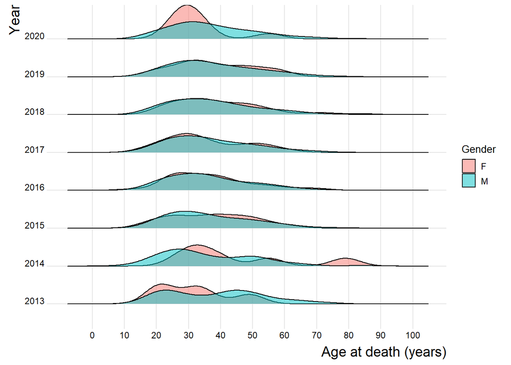

```r
library(ggplot2)
library(ggridges)
data <- read_csv("data/policekillings202110.csv")
data %>%
  filter(Gender %in% c("F", "M", "T")) %>%
  filter(!is.na(Year)) %>%
  ggplot(aes(x = Age,
             y = factor(Year),
             fill = Gender)) +
  geom_density_ridges(alpha = 0.5,
                      scale = 0.9)  +
  theme_ridges(font_size = 10) +
  scale_x_continuous(breaks = seq(0, 100, 10),
                     labels = seq(0, 100, 10)) +
  xlab("Age at death (years)") +
  ylab("Year") +
  theme(axis.title = element_text(size = 14))
```

We can see, however, that with time the age is centering more around 30 rather than 20.

### Race

Of the three ethnic groups that make up most of the deaths, Black and Latino people tend to be younger than White people when they are killed by police.

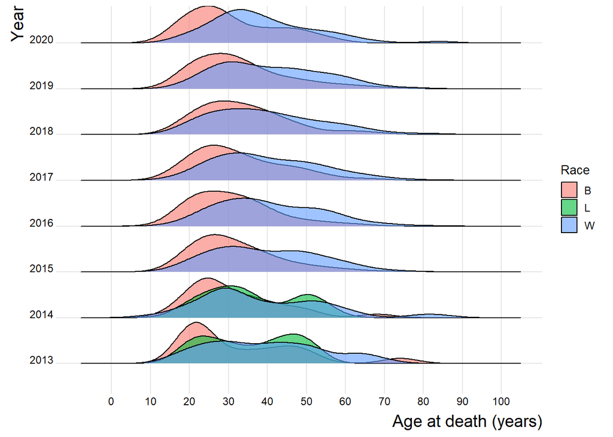

```r
library(tidyverse)

data %>%
  filter(Race %in% c("B", "W", "L")) %>%
  filter(!is.na(Year)) %>%
  ggplot(aes(x = Age,
             y = factor(Year),
             fill = Race)) +
  geom_density_ridges(alpha = 0.6,
                      scale = 0.9)  +
  theme_ridges(font_size = 10) +
  scale_x_continuous(breaks = seq(0, 100, 10),
                     labels = seq(0, 100, 10)) +
  xlab("Age at death (years)") +
  ylab("Year") +
  theme(axis.title = element_text(size = 14))
```

## Method

By far the most common way that people are killed by police is with a gun. Deaths by vehicle involve women more often than men. Other methods are less common, and frankly, I do not know what the acronyms stand for (R, T, U..)

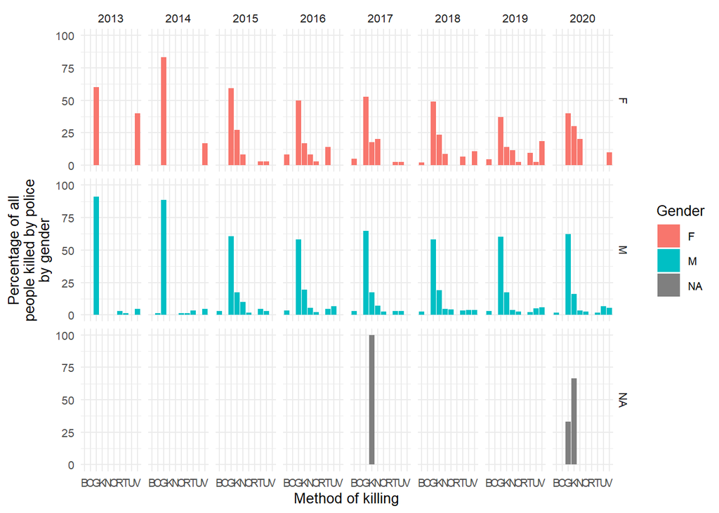

```r
data %>%
  filter(!is.na(Year)) %>%
  filter(Method != "NA") %>%
  filter(Gender %in% c("M", "F", NA)) %>%
  group_by(Year,
           Gender,
           Method) %>%
  tally() %>%
  mutate(perc = n / sum(n) * 100)  %>%
  ggplot(aes(Method,
             perc,
             fill = Gender)) +
  geom_col() +
  facet_grid(Gender~Year) +
  theme_minimal(base_size = 10) +
  xlab("Method of killing") +
  ylab("Percentage of all\npeople killed by police\nby gender")
```

## Map casualties by state

In 2016, the state with the largest number of people killed by police was California.

```r
#install.packages(c("statebins", "viridis"))
library(statebins) # using GitHub version
library(viridis)
# we need to convert state abbreviations to state names for the statebins function
state_abb <- data_frame(state_name = state.name,
                        state_abb = state.abb)
# we need to add the state popluations so we can get a proportion of people in each state
# we got this from https://www2.census.gov/programs-surveys/popest/tables/2010-2016/state/totals/nst-est2016-01.xlsx
state_populations <- readr::read_csv("data-raw/nst-est2016-01.csv")
# clean it a little
state_populations <-
  state_populations %>%
  mutate(state_name = gsub("\\.", "", X__1)) %>%
  left_join(state_abb)
# compute deaths by state and as deaths per 1000 people in each state
by_state16 <- data %>%
  filter(Year == 2016) %>%
  group_by(State) %>%
  tally() %>%
  left_join(state_abb, by = c('State' = 'state_abb')) %>%
  filter(!is.na(state_name)) %>%
  left_join(state_populations) %>%
  mutate(per_n_people = (n / `2016`) * 1000000)
```

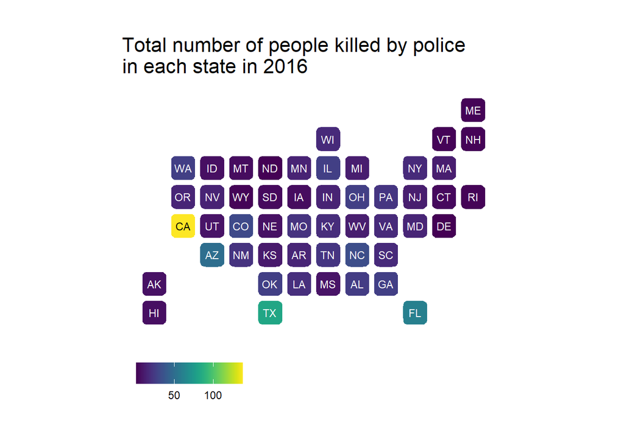

```r
# plot 'statebin' style map
ggplot(by_state16,
       aes(state = state_name,
           fill = n)) +
  geom_statebins() +
  coord_equal() +
  scale_fill_viridis() +
  theme_statebins() +
  labs(title = "Total number of people killed by police \nin each state in 2016") +
  theme(legend.title=element_blank())
```

The difference between 2016 and 2019 is hardly visible, with the exception of Texas. I downloaded this census on 20 July from https://www2.census.gov/programs-surveys/popest/tables/2010-2019/state/asrh/

```r
state_population19 <- readr::read_csv("data-raw/sc-est2019-alldata5.csv")
# clean it a little
state_pop17_19 <- state_population19 %>%
    group_by(NAME) %>%
    summarize(pop2017= sum(POPESTIMATE2017), pop2018 = sum(POPESTIMATE2018), pop2019=sum(POPESTIMATE2019)) %>%
    rename(state_name = NAME)
state_pop17_19 %>%
    select(state_name, pop2017) %>%
    glimpse()
```

```
## Rows: 51
## Columns: 2
## $ state_name <chr> "Alabama", "Alaska", "Arizona", "Arkansas", "California"...
## $ pop2017    <dbl> 19848340, 3195164, 29037264, 12270976, 164140492, 231887...
```

```r
# compute deaths by state and as deaths per 1000 people in each state
by_state19 <- data %>%
  filter(Year == 2019) %>%
  group_by(State) %>%
  tally() %>%
  left_join(state_abb, by = c('State' = 'state_abb')) %>%
  filter(!is.na(state_name)) %>%
  left_join(state_pop17_19) %>%
  mutate(per_n_people = (n / `pop2019`) * 1000000)
```

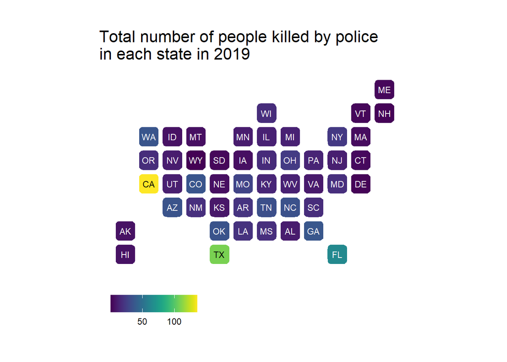

```r
# plot 'statebin' style map
ggplot(by_state19,
       aes(state = state_name,
           fill = n)) +
  geom_statebins() +
  coord_equal() +
  scale_fill_viridis() +
  theme_statebins() +
  labs(title = "Total number of people killed by police \nin each state in 2019") +
  theme(legend.title=element_blank())
```

Let’s now divide the totals by the number of people in each state: in 2016, New Mexico and Alaska have the highest proportions of people killed by police.

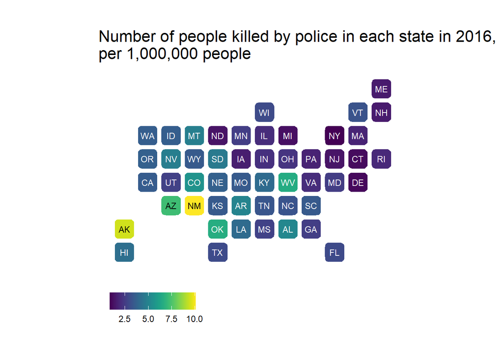

```r
ggplot(by_state16,
       aes(state = state_name,
           fill = per_n_people)) +
  geom_statebins() +
  coord_equal() +
  scale_fill_viridis() +
  theme_statebins() +
  labs(title = "Number of people killed by police in each state in 2016,\nper 1,000,000 people")  +
  theme(legend.title=element_blank())
```

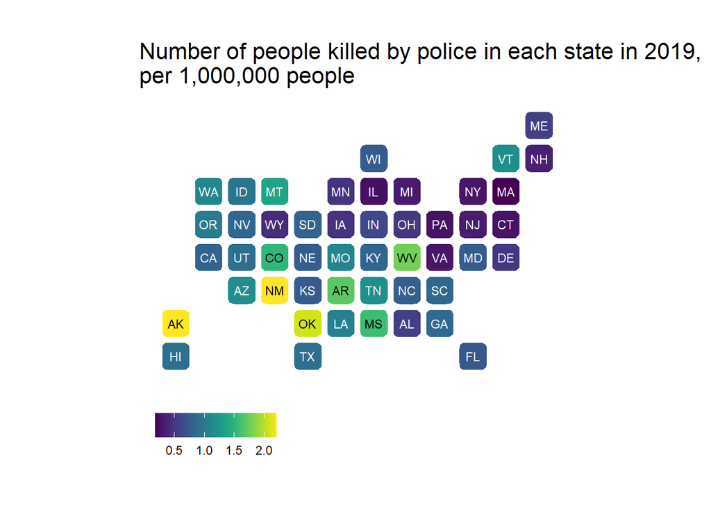

```r
ggplot(by_state19,
       aes(state = state_name,
           fill = per_n_people)) +
  geom_statebins() +
  coord_equal() +
  scale_fill_viridis() +
  theme_statebins() +
  labs(title = "Number of people killed by police in each state in 2019,\nper 1,000,000 people")  +
  theme(legend.title=element_blank())
```

Now it is your turn. Apply the webscraping part of this script to a subject of your own! (But consider what you can use the output for first :)